# Cluster and Factor Analysis of Country Data

## Cluster Analysis

```r
# clean memory
rm(list = ls())

# reading in data via Github link
file <-("https://github.com/Policy-by-the-Numbers/deliverable2/raw/main/deli2dataset_new.csv")
data <-read.csv(file, row.names=NULL)

# reset indexes to R paradigm


#check data types
str(data)
```

```
'data.frame':   146 obs. of  13 variables:
 $ name                   : chr  "Afghanistan" "Albania" "Algeria" "Angola" ...
 $ percentgdpeduc         : num  2.9 3.1 7 2.4 5 2.8 6.1 5.1 4.3 2.1 ...
 $ gini                   : num  29.4 30.8 27.6 51.3 42.3 25.2 34.3 30.2 33.7 32.4 ...
 $ deathsperthoulivebirths: num  104.89 10.82 19.72 58.86 9.35 ...
 $ inflationrate          : num  2.3 2.04 7.23 25.75 25.7 ...
 $ migrantsperthousand    : num  -0.1 -3.23 -0.82 -0.19 -0.08 -5.36 6.93 3.55 0 -2.9 ...
 $ unemploymentrate       : num  13.28 11.82 12.7 8.53 10.9 ...
 $ mtonsco2emissions      : num  7.89e+06 3.79e+06 1.52e+08 1.94e+07 1.93e+08 ...
 $ btuperperson           : int  3227000 38442000 61433000 11693000 79083000 53019000 241004000 171299000 64416000 9917000 ...
 $ childrenperwoman       : num  4.62 1.54 2.51 5.83 2.18 1.65 1.73 1.51 1.86 2.09 ...
 $ percentgdpmilitary     : num  3.3 1.6 5.6 1.4 0.8 4.4 2 0.7 5.2 1.1 ...
 $ alcliterspercapita     : num  0.01 4.4 0.59 5.84 7.95 3.77 9.51 11.9 1.38 0 ...
 $ internetusers          : int  7007101 2043251 27626157 11831857 39853610 2288566 23123940 7846840 8745304 41172346 ...
```

```r
# Preparing data

# I think we want to keep all of these variables but the name
clusterData=data[,c(2:13)]

#save the country names as the row index
row.names(clusterData)=data$name

clusterData
```

|  | percentgdpeduc | gini | deathsperthoulivebirths | inflationrate | migrantsperthousand | unemploymentrate | mtonsco2emissions | btuperperson | childrenperwoman | percentgdpmilitary | alcliterspercapita | internetusers |
| --- | --- | --- | --- | --- | --- | --- | --- | --- | --- | --- | --- | --- |
| Afghanistan | 2.9 | 29.4 | 104.89 | 2.30 | -0.10 | 13.28 | 7893000 | 3227000 | 4.62 | 3.30 | 0.01 | 7007101 |
| Albania | 3.1 | 30.8 | 10.82 | 2.04 | -3.23 | 11.82 | 3794000 | 38442000 | 1.54 | 1.60 | 4.40 | 2043251 |
| Algeria | 7.0 | 27.6 | 19.72 | 7.23 | -0.82 | 12.70 | 151633000 | 61433000 | 2.51 | 5.60 | 0.59 | 27626157 |
| Angola | 2.4 | 51.3 | 58.86 | 25.75 | -0.19 | 8.53 | 19362000 | 11693000 | 5.83 | 1.40 | 5.84 | 11831857 |
| Argentina | 5.0 | 42.3 | 9.35 | 25.70 | -0.08 | 10.90 | 193205000 | 79083000 | 2.18 | 0.80 | 7.95 | 39853610 |
| Armenia | 2.8 | 25.2 | 12.18 | 7.18 | -5.36 | 20.90 | 6354000 | 53019000 | 1.65 | 4.40 | 3.77 | 2288566 |
| Australia | 6.1 | 34.3 | 3.01 | 2.86 | 6.93 | 5.11 | 417870000 | 241004000 | 1.73 | 2.00 | 9.51 | 23123940 |
| Austria | 5.1 | 30.2 | 3.24 | 2.77 | 3.55 | 6.30 | 65540000 | 171299000 | 1.51 | 0.70 | 11.90 | 7846840 |
| Azerbaijan | 4.3 | 33.7 | 23.51 | 6.65 | 0.00 | 6.58 | 35389000 | 64416000 | 1.86 | 5.20 | 1.38 | 8745304 |
| Bangladesh | 2.1 | 32.4 | 30.35 | 5.55 | -2.90 | 5.23 | 96180000 | 9917000 | 2.09 | 1.10 | 0.00 | 41172346 |

[output cut: 136 more lines]

```r
# computing distance matrix

set.seed(999)
```

```r
library(cluster)
distanceMatrix=daisy(x=clusterData, metric = "gower")
```

```r
projectedData = cmdscale(distanceMatrix, k=2)
```

```r
# save coordinates to original data frame:
data$dim1 = projectedData[,1]
data$dim2 = projectedData[,2]

# see some:

data[,c('dim1','dim2')][1:10,]
```

|  | dim1 | dim2 |
| --- | --- | --- |
| 1 | -0.16217651 | 0.060520241 |
| 2 | 0.01293624 | 0.011127105 |
| 3 | -0.01589943 | 0.122897081 |
| 4 | -0.11550563 | -0.097910183 |
| 5 | 0.04189793 | -0.041921404 |
| 6 | 0.01048922 | 0.097111321 |
| 7 | 0.11715353 | -0.002678578 |
| 8 | 0.11844008 | -0.040271433 |
| 9 | -0.01350670 | 0.098314863 |
| 10 | -0.05006513 | 0.019717889 |

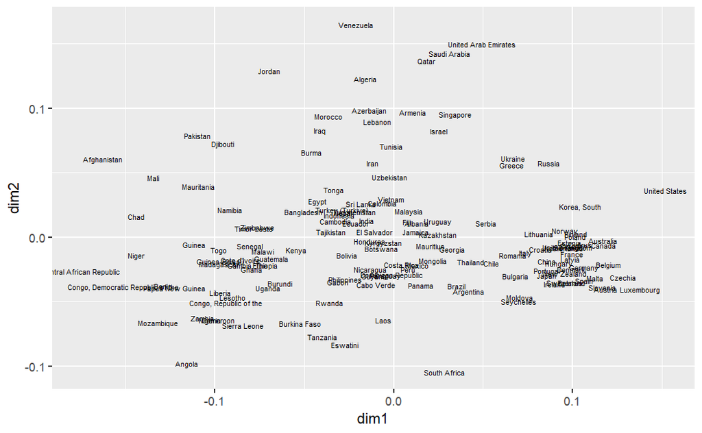

```r
library(ggplot2)
base= ggplot(data=data,
             aes(x=dim1, y=dim2,
                 label=name))
base + geom_text(size=2)
```

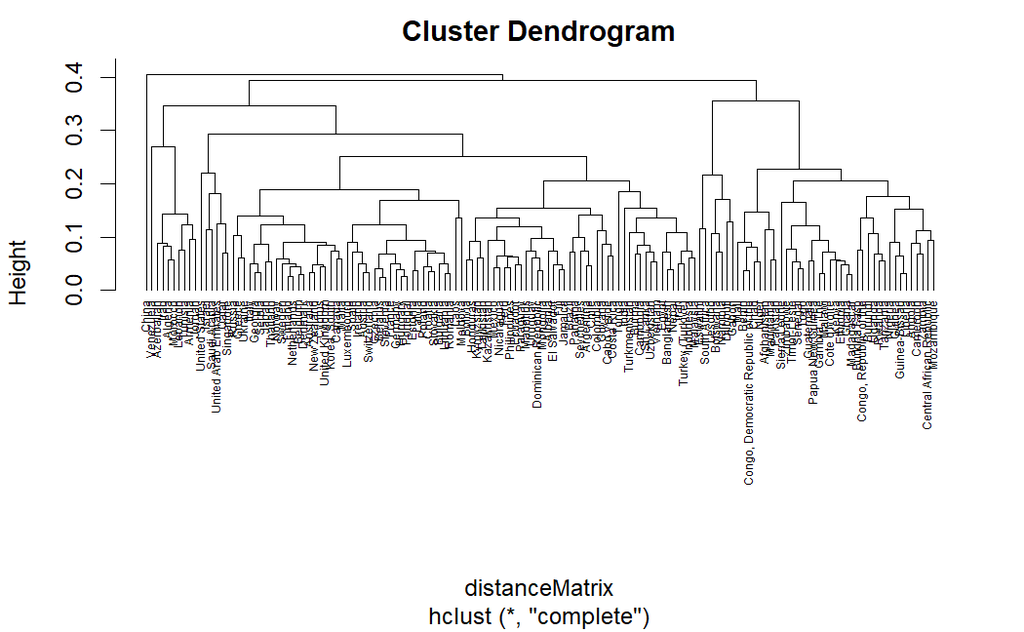

```r
# prepare hierarchical cluster
hc = hclust(distanceMatrix)
# very simple dendrogram
plot(hc,hang = -1,cex=0.5)
```

```r
# Computing clusters
library(factoextra)
```

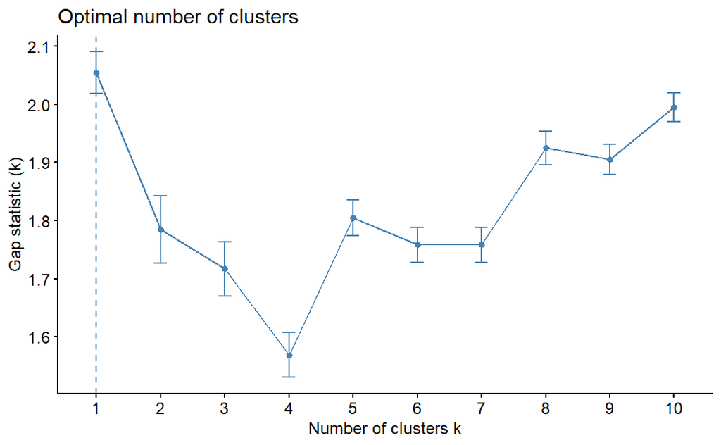

```r
# Hierarchical (agglomerative) method:

fviz_nbclust(clusterData,
             hcut,
             diss=distanceMatrix,
             method = "gap_stat",
             k.max = 10,
             verbose = F,
             hc_func = "agnes")
```

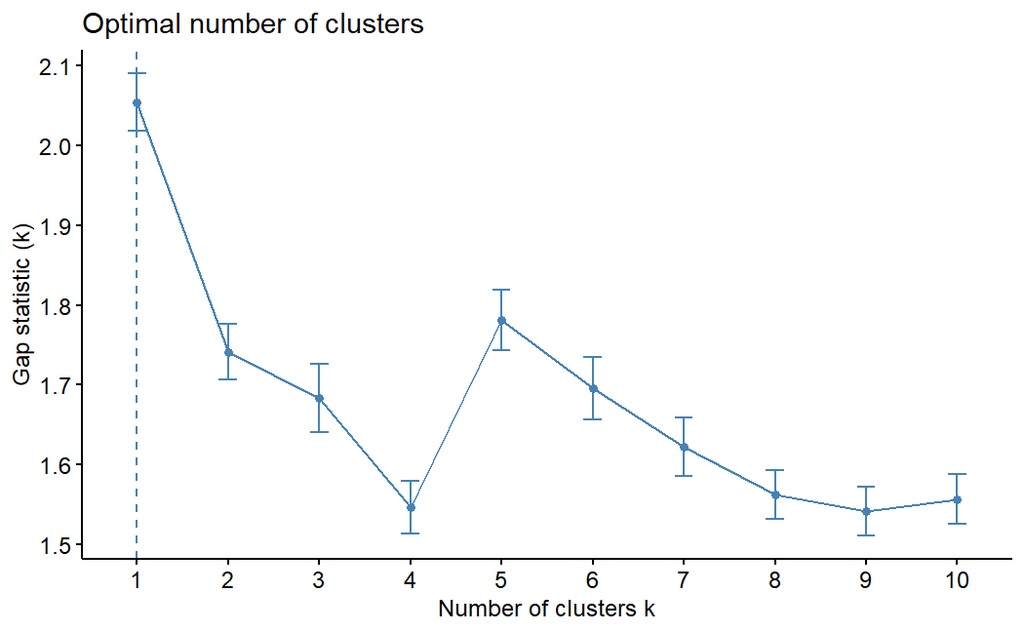

```r
# Hierarchical (divisive) method:
fviz_nbclust(clusterData,
             hcut,
             diss=distanceMatrix,
             method = "gap_stat",
             k.max = 10,
             verbose = F,
             hc_func = "diana")
```

2. Computing Clusters

```r
# Computing clusters:

NumberDesiredClusters=1 #both methods had 1 as optimal no. of clusters
# this doesn't even mean anything

# Hierarchical - agglom:
res.agnes= hcut(distanceMatrix,
                k = NumberDesiredClusters,
                isdiss=TRUE,
                hc_func='agnes',
                hc_method = "ward.D2")

# Hierarchical - divisive:
res.diana= hcut(distanceMatrix,
                k = NumberDesiredClusters,
                isdiss=TRUE,
                hc_func='diana',
                hc_method = "ward.D2")
```

3. Results from Clustering

```r
# Results from Clustering

# Saving results to original dataframe
data$agn=as.factor(res.agnes$cluster)
data$dia=as.factor(res.diana$cluster)
```

```r
# verify ordinality in clusters

 #aggregate(data=fromPy,
         #Overallscore~agn,
          #UN=mean)

##aggregate(data=fromPy,
           #Overallscore~dia,
            #UN=mean)

# this part is confusing to me
# may not be necessary for this dataset?
```

4. Evaluating Results

```r
# Plot silhouettes
# agglom silh
fviz_silhouette(res.agnes)
```

[output not shown]

[output not shown]

[figure not shown]

```r
# divisive silh
fviz_silhouette(res.diana)
```

```r
# detecting cases wrongly clustered

#saving individual silhouettes
agnEval=data.frame(res.agnes$silinfo$widths)
diaEval=data.frame(res.diana$silinfo$widths)

agnPoor=rownames(agnEval[agnEval$sil_width<0,])
diaPoor=rownames(diaEval[diaEval$sil_width<0,])
```

```r
# now seeing which countries are not well clustered
library("qpcR")
```

[output not shown]

How to compare clustering?

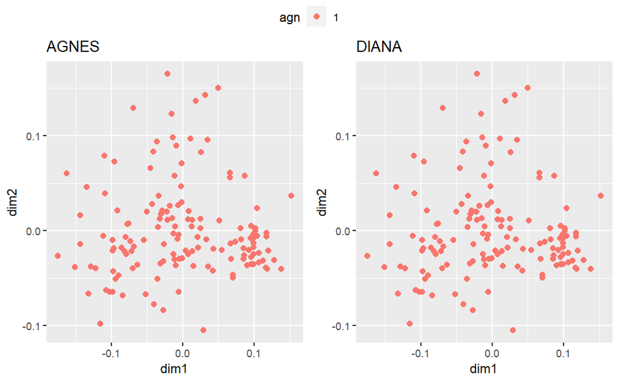

```r
# hierarchical agglom:
base= ggplot(data=data,
             aes(x=dim1, y=dim2,
                 label=name))
agnPlot=base + labs(title = "AGNES") + geom_point(size=2,
                                              aes(color=agn),
                                              show.legend = T)


# hierarchical diana:
diaPlot=base + labs(title = "DIANA") + geom_point(size=2,
                                              aes(color=dia),
                                              show.legend = T)

# compare visually:
library(ggpubr)

ggarrange(agnPlot, diaPlot,ncol = 2,common.legend = T)
```

Producing dendograms for the results

[figure not shown]

```r
# Agglomerative
fviz_dend(res.agnes,
          k=NumberDesiredClusters,
          cex = 0.45,
          horiz = T,
          main = "AGNES approach")
```

[figure not shown]

```r
# Divisive approach:
fviz_dend(res.diana,
          k=NumberDesiredClusters,
          cex = 0.45,
          horiz = T,
          main = "DIANA approach")
```

We fail to find any meaningful results from the clustering data because it grouped all the countries into one cluster. Let’s try a factor analysis of the same country-level data.

1. Subset original data frame

```r
FAdata=clusterData
```

2. Compute correlations

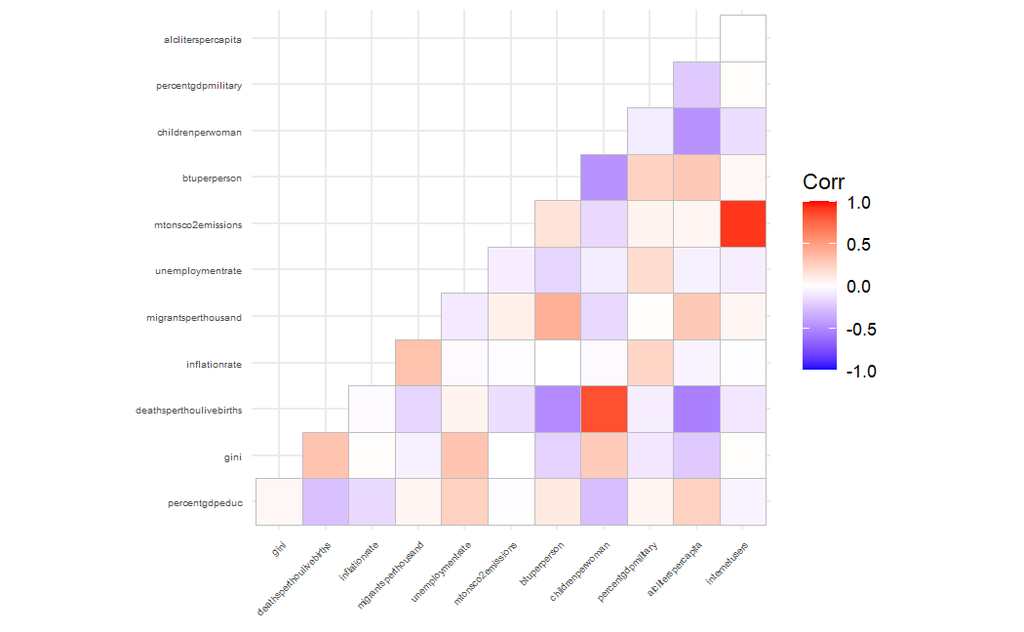

```r
library(polycor)
corMatrix=polycor::hetcor(FAdata)$correlations

# visualizing matrix
library(ggcorrplot)
ggcorrplot(corMatrix,
           type = "lower") +
          theme(axis.text.x  = element_text(size = 5),
                axis.text.y  = element_text(size = 5))
```

```r
# looks terrible tbh
```

3. check conditions

```r
# the amount of data should be enough for the correlation process:
library(psych)
psych::KMO(corMatrix)
```

```
Kaiser-Meyer-Olkin factor adequacy
Call: psych::KMO(r = corMatrix)
Overall MSA =  0.57
MSA for each item =
         percentgdpeduc                    gini deathsperthoulivebirths
                   0.71                    0.61                    0.69
          inflationrate     migrantsperthousand        unemploymentrate
                   0.33                    0.49                    0.37
      mtonsco2emissions            btuperperson        childrenperwoman
                   0.49                    0.59                    0.66
     percentgdpmilitary      alcliterspercapita           internetusers
                   0.33                    0.74                    0.47
```

```r
# literally just barely meets the threshold for KMO
```

The correlation matrix should not be an identity matrix:

```r
# is identity matrix?
cortest.bartlett(corMatrix,n=nrow(FAdata))$p.value>0.05
```

```
[1] FALSE
```

The correlation matrix should not be singular

```r
library(matrixcalc)

is.singular.matrix(corMatrix)
```

```
[1] FALSE
```

4. Get suggestions for amount of clusters

```r
fa.parallel(FAdata, fa = 'fa',correct = T,plot = F)
```

```
Parallel analysis suggests that the number of factors =  5  and the number of components =  NA
```

5. Compute the factors

```r
library(GPArotation)
resfa <- fa(FAdata,
            nfactors = 5,
            cor = 'mixed',
            rotate = "varimax",
            fm="minres")
```

6. Explore results

```r
### see results
print(resfa$loadings,cutoff = 0.5)
```

```
Loadings:
                        MR1    MR2    MR4    MR3    MR5
percentgdpeduc
gini
deathsperthoulivebirths  0.930
inflationrate
migrantsperthousand                    0.974
unemploymentrate                                     0.911
mtonsco2emissions               0.921
btuperperson            -0.520
childrenperwoman         0.870
percentgdpmilitary                            0.989
alcliterspercapita      -0.603
internetusers                   0.997

                 MR1   MR2   MR4   MR3   MR5
SS loadings    2.527 1.870 1.173 1.156 1.081
Proportion Var 0.211 0.156 0.098 0.096 0.090
Cumulative Var 0.211 0.366 0.464 0.561 0.651
```

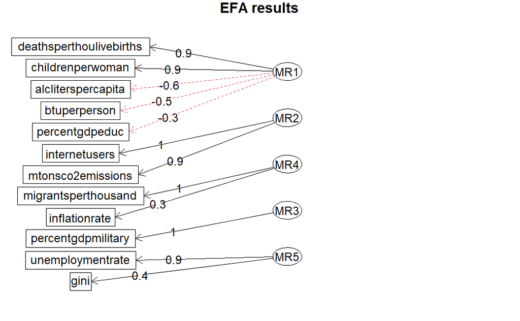

```r
fa.diagram(resfa,main = "EFA results")
```

8. Improving factor analysis

```r
ps=c("mtonsco2emissions", "alcliterspercapita", "percentgdpmilitary", "internetusers")
notPs=setdiff(names(FAdata),ps)
FAdata2=FAdata[,notPs]
```

recompute correlations

```r
library(polycor)
corMatrix2=polycor::hetcor(FAdata2)$correlations
```

Recheck conditions: MSA

```r
library(psych)
psych::KMO(corMatrix2)
```

```
Kaiser-Meyer-Olkin factor adequacy
Call: psych::KMO(r = corMatrix2)
Overall MSA =  0.61
MSA for each item =
         percentgdpeduc                    gini deathsperthoulivebirths
                   0.67                    0.72                    0.63
          inflationrate     migrantsperthousand        unemploymentrate
                   0.40                    0.54                    0.42
           btuperperson        childrenperwoman
                   0.73                    0.61
```

```r
# MSA improved!
```

Recheck conditions: bartlett

```r
cortest.bartlett(corMatrix2,n=nrow(FAdata2))$p.value>0.05
```

```
[1] FALSE
```

Recheck conditions: singularity

```r
library(matrixcalc)

is.singular.matrix(corMatrix2)
```

```
[1] FALSE
```

Now get new suggestions

```r
fa.parallel(FAdata2, fa = 'fa',correct = T,plot = F)
```

```
Parallel analysis suggests that the number of factors =  3  and the number of components =  NA
```

Compute factors again

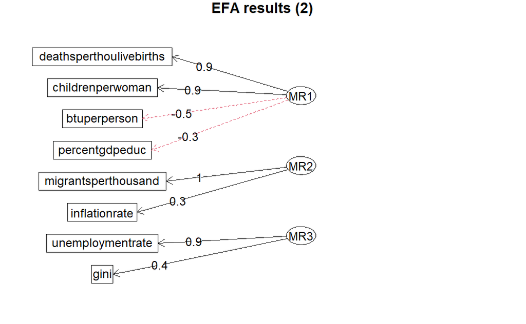

```r
library(GPArotation)
resfa <- fa(FAdata2,
            nfactors = 3,
            cor = 'mixed',
            rotate = "varimax",
            fm="minres")
# Displaying results
fa.diagram(resfa,main = "EFA results (2)")
```

We end up with three factors: MR1 has child mortality rate, total fertility rate, education expeditures (negatively correlated) and energy consumption per capita (negatively correlated) as components, MR2 has net migration rate and inflation rate as components, and MR3 has unemployment rate and gini coefficent as components. I hypothesize that MR1 represents the latent concept of a country’s development level as I expect chid mortality rate and total fertility rate to be positively correlated with development level and education expenditures and energy consumption to be negatively correlated with a country’s development level. I hypothesize that MR3 represents a country’s inequality, as that factor is positively correlated with the Gini coefficient and unemployment rate. This is a stretch but I hypothesize MR2 to represent scarcity, as scarcity is positively correlated with inflation rate and migration rate. It should be noted though, that with an MSA of 0.61, the factor scores are likely not completely accurate.